# Lululemon Recovery Strategy

*Oxford Road — February 2026*

This analysis covers the financial decline, competitive threats, customer base, and marketing channel opportunities — with 185+ data points extracted from public sources and industry research.

## The Headline Numbers

[output not shown]

## What’s Happening

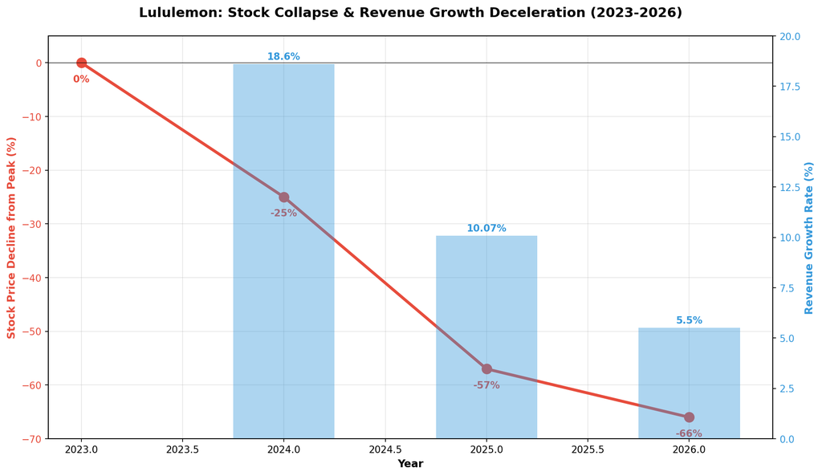

Stock and revenue decline timeline

The stock tells the story: down 66% even as absolute revenue grows. The market sees a company whose growth engine is stalling — from 18.6% revenue growth in 2024 to a projected 5.5% in 2026. Gross margins are compressing (down 110 basis points). Americas comparable sales turned negative.

## Who’s Taking Share

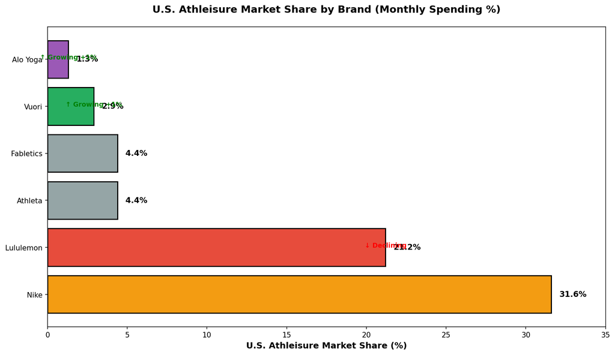

Market share comparison across athleisure brands

Lululemon still holds 21.2% of U.S. athleisure spending — second only to Nike. But the smaller brands below them are growing faster.

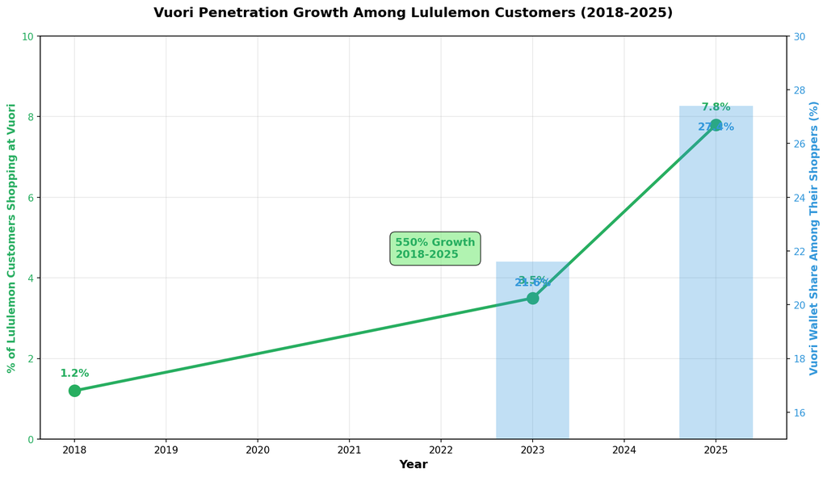

Vuori penetration growth among Lululemon customers

**Vuori is the existential threat.** In 2018, just 1.2% of Lululemon customers also shopped at Vuori. By 2025, that’s 7.8% — a 550% increase. Critically, those customers now spend *more* at Vuori ($660) than at Lululemon ($600). Vuori is targeting 100 stores by 2026.

**Alo Yoga** jumped from 35th to 11th in teen brand rankings in just 12 months. 63% of Alo shoppers are also Lululemon customers.

## Why It’s Happening

1. **Product got predictable.** CEO admitted the brand became “too predictable.” Gen Z is shifting to baggier fits; Lululemon’s design cycle is slower than competitors.
2. **Price sensitivity rising.** 82% of consumers are changing shopping habits due to tariff concerns. Core leggings in outlet stores (unprecedented).
3. **Competitors are faster.** Vuori grows at 23% YoY. Alo Yoga’s Instagram-first strategy captures younger customers. Both are opening stores near Lululemon locations.
4. **Leadership vacuum.** Calvin McDonald departed Jan 31, 2026. Founder Chip Wilson ran a public campaign against management, citing “brand erosion.”

## The Marketing Opportunity

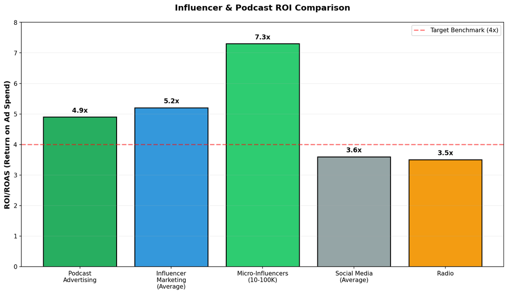

ROI comparison across marketing channels

| Channel | ROI | Trust | Why It Works |
| --- | --- | --- | --- |
| Micro-influencers (10-100K) | **7.3x** | 67% (TikTok) | Highest engagement at 7.3%, 60% higher CTR than standard ads |
| Podcast host-read ads | **4.9x** | **62%** | 86% brand recall lift, 73% listener receptivity |
| Social media (average) | 3.6x | 15% | Lower trust, lower recall |

Podcast listeners trust host-read ads at **4x the rate** of social media influencers (62% vs 15%). Fitness influencers achieve 18.36% engagement — the highest of any category.

## The Customer

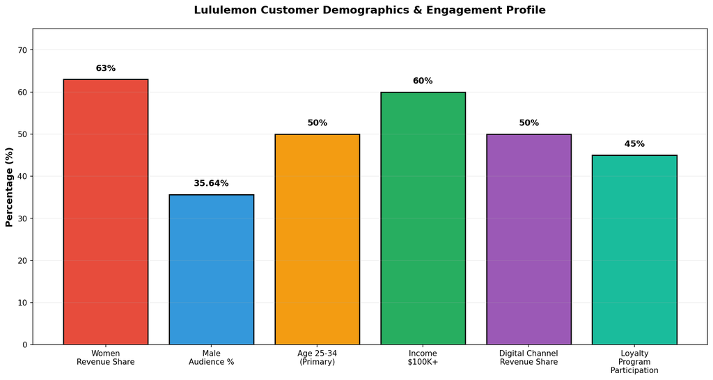

Customer demographics breakdown

| Dimension | Profile |
| --- | --- |
| Gender | 63% women, 70% female customers |
| Age | Primary 25-34, target 18-49 |
| Income | $100K+ household (60% of sales) |
| Digital | 50% of revenue from digital channels |
| Loyalty | 45% program participation (opportunity) |
| Retention | 72-76% overall, 92% for top 20% |
| NPS | 41 (4th in fashion/beauty category) |

83% of customers self-identify as loyal. But only 45% participate in the loyalty program — a clear engagement gap.

## What To Do About It

**Integrated micro-influencer + podcast strategy** targeting Lululemon’s core demo (women 25-45, $100K+ HHI, fitness-engaged):

- **50-75 micro-influencers** on long-term partnerships ($700-$1,200/month), focused on authentic training content
- **3-5 primary podcast sponsorships** with host-read ads in fitness/wellness shows ($25-$45 CPM)
- **150-200 nano-influencers** for hyper-local activations in key cities
- **Quarterly community wellness challenges** tied to loyalty program enrollment

**Expected Year 1:** 25K-50K new customers, $5M-$15M revenue impact, 25-35% repeat purchase improvement at $30-$60 CPA (vs $150-$300 traditional).

*Navigate: Key Numbers & Charts · Full Research · Complete Data (185+ metrics)*